# Paired T-Test

Homework Quiz

Author

Nathan Lunceford

# Helmet Measurements

After purchasing a batch of flight helmets that did not fit the heads of many pilots, the NZ Airforce decided to measure the head sizes of all recruits. Before this was carried out, information was collected to determine the feasibility of using cheap cardboard calipers to make the measurements, instead of metal ones which were expensive and uncomfortable.

The data lists the head diameters of 18 recruits measured once using cardboard calipers and again using metal calipers. One question is whether there is *any* systematic difference between the two measurement tools.

**NOTE**: Define the difference as cardboard - metal.

Use $\alpha = 0.05$ significance level.

## Step 1: Load the Data

```r
library(tidyverse)
library(mosaic)
library(rio)
library(car)

helmet_fit <- import("https://byuistats.github.io/M221R/Data/quiz/R/helmet_fit.csv")
```

## Step 2: Explore the Data and Generate Hypotheses

Create histograms and summary statistic tables for the measurements for each type of tool:  
**Cardboard**

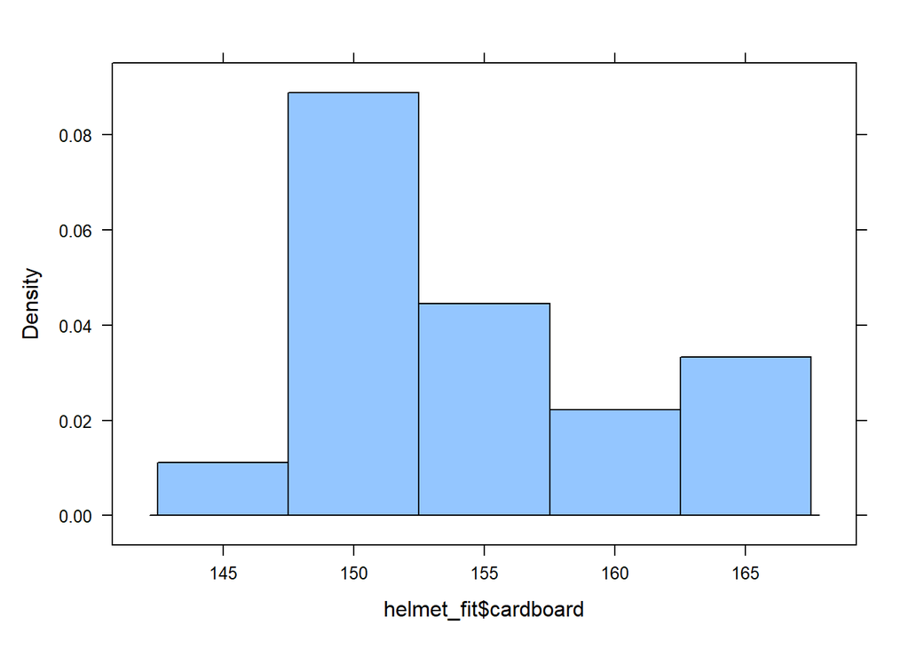

```r
histogram(helmet_fit$cardboard)
```

```r
fav <- favstats(helmet_fit$cardboard)
fav
```

```
 min     Q1 median    Q3 max     mean     sd  n missing
 146 150.25  153.5 157.5 166 154.5556 5.8231 18       0
```

**Metal**

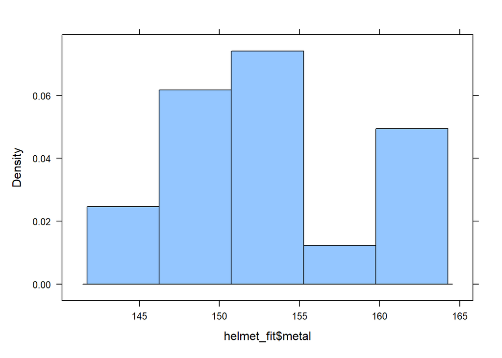

```r
histogram(helmet_fit$metal)
```

```r
fav <- favstats(helmet_fit$metal)
fav
```

```
 min  Q1 median    Q3 max     mean       sd  n missing
 145 150  152.5 155.5 163 152.9444 5.535683 18       0
```

## Step 3: Prepare the data for analysis

Give the summary statistics (favstats) for the *differences* in the measured head diameters.

What does a negative number mean given the definition of the difference?

```r
diff <- helmet_fit$cardboard - helmet_fit$metal
fav <- favstats(diff)
fav
```

```
 min Q1 median   Q3 max     mean       sd  n missing
  -2  1    1.5 2.75   6 1.611111 2.145827 18       0
```

**A negative number in the differences means that the metal caliper measurement is larger than the cardboard caliper measurement.**

Create a histogram and a qqPlot of the differences:

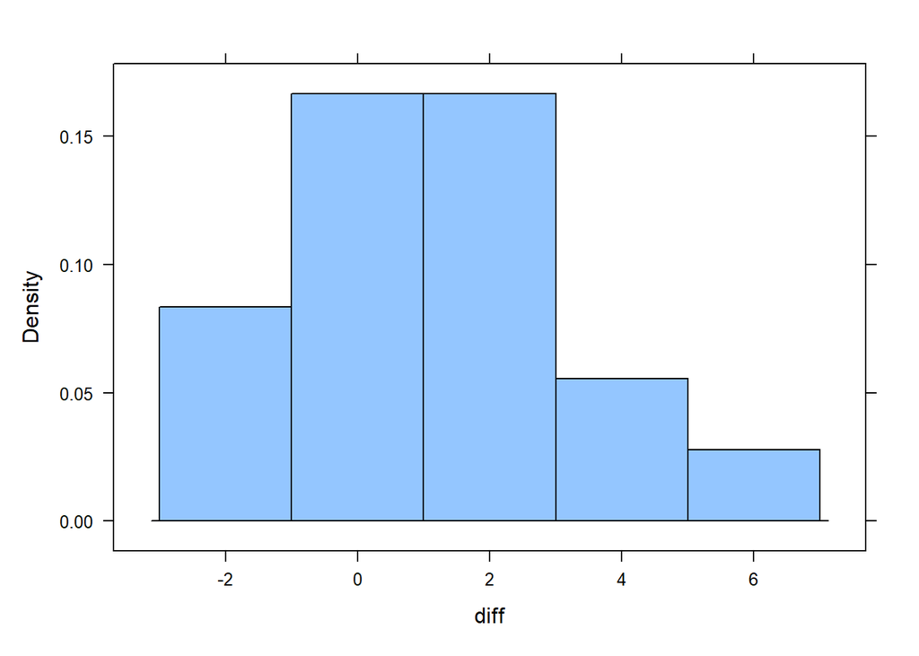

```r
histogram(diff)
```

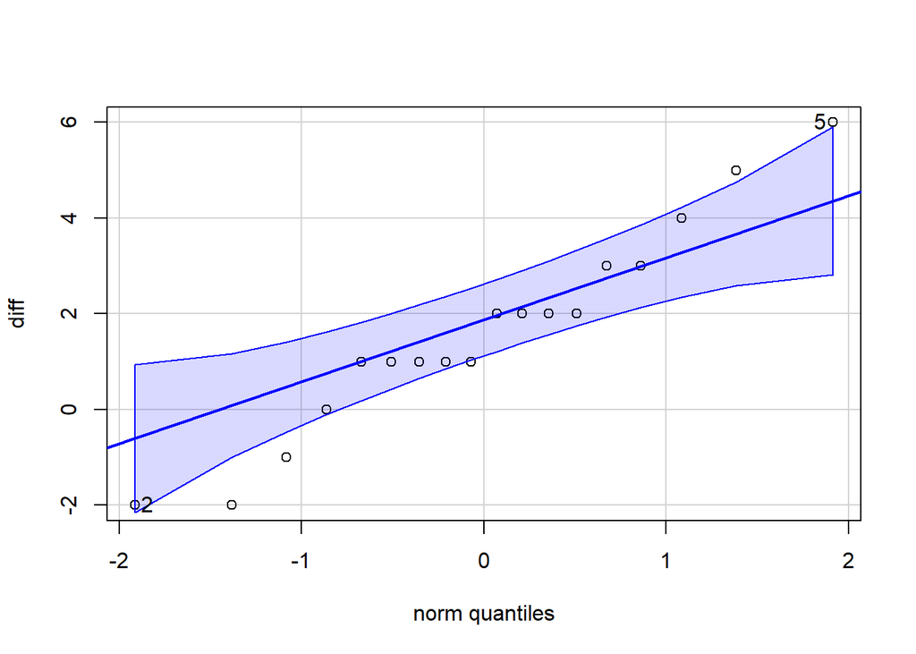

```
[1] 5 2
```

```r
qqPlot(diff)
```

## Step 4: Perform the Appropriate Analyses

### Hypothesis Test

Make the following null and alternative hypothesis correct by deleting what doesn’t belong:

$$H_0: \mu_d = 0$$

$$H_a: \mu_d \ne 0$$

```r
# Perform a t-test for the mean of the differences between cardboard and caliper data
t_test_results <- t.test(diff, mu = 0, alternative = "two.sided")

# Print the test statistic, degrees of freedom, and p-value
t_test_results
```

```
    One Sample t-test

data:  diff
t = 3.1854, df = 17, p-value = 0.005415
alternative hypothesis: true mean is not equal to 0
95 percent confidence interval:
 0.5440163 2.6782060
sample estimates:
mean of x
 1.611111
```

What is the value of the test statistic, $t$?  
**t = 3.1854**

How many degrees of freedom does this test statistics have?  
**df = 17**

What is the P-value?  
**p-value = 0.005415**

Can we trust this P-value?

1. How many differences in our sample?  
   **18**
2. Check the `qqPlot()` of the differences for normality: **We can assume normality because the qqPlot shows that the points generally follow a straight line.**

State your conclusion about the hypothesis test:  
**Since the p-value (0.005415) is less than the significance level, we reject the null hypothesis. This indicates that there is a statistically significant difference between the head diameter measurements taken with cardboard calipers and metal calipers.**

### Confidence Intervals

Create a 95% confidence interval for the true average difference between the cardboard and the metal measurement tools:

```r
conf_int <- t_test_results$conf.int
conf_int
```

```
[1] 0.5440163 2.6782060
attr(,"conf.level")
[1] 0.95
```

Give a one-sentence explanation of your confidence interval:  
**We are 95% confident that the true mean difference in head diameter measurements between the cardboard and metal calipers lies between 0.544 and 2.678.**

# Cholesterol

A study was conducted at a major northeastern American medical center regarding blood cholesterol levels and heart-attack incidents. A total of 28 heart-attack patients had their cholesterol levels measured two days after the heart attack and again four days after the heart attack. Researchers want to see if cholesterol levels reduced significantly four days after the attack versus two days after the attack.

Use the level of significance of 0.05.

## Step 1: Load the Data

```r
cholesterol <- import("https://byuistats.github.io/M221R/Data/quiz/R/cholesterol.csv")
glimpse(cholesterol)
```

```
Rows: 28
Columns: 3
$ patient   <int> 1, 2, 3, 4, 5, 6, 7, 8, 9, 10, 11, 12, 13, 14, 15, 16, 17, 1…
$ chol_day2 <int> 270, 236, 210, 142, 280, 272, 160, 220, 226, 242, 186, 266, …
$ chol_day4 <int> 218, 234, 214, 116, 200, 276, 146, 182, 238, 288, 190, 236, …
```

## Step 2: Review the Data Generate Hypotheses

Create histograms and summary statistics tables for the cholesterol measurements at 2 days and at 4 days. **Cholesterol 2 Days**

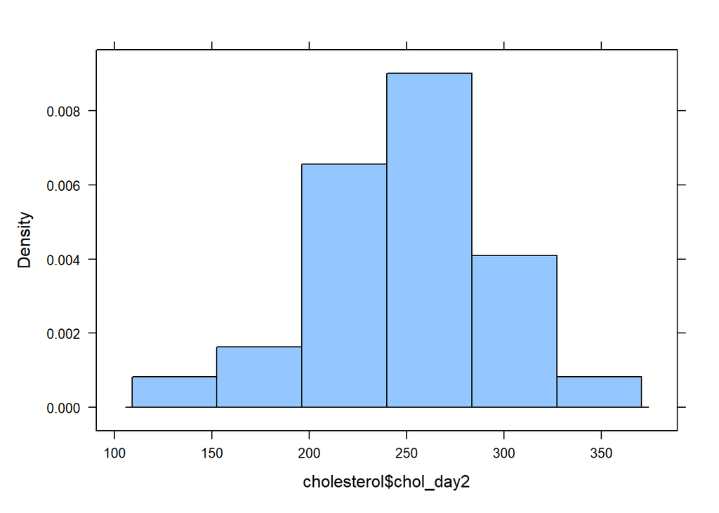

```r
histogram(cholesterol$chol_day2)
```

```r
fav <- favstats(cholesterol$chol_day2)
fav
```

```
 min    Q1 median  Q3 max     mean       sd  n missing
 142 225.5    268 282 360 253.9286 47.71049 28       0
```

**Cholesterol 4 Days**

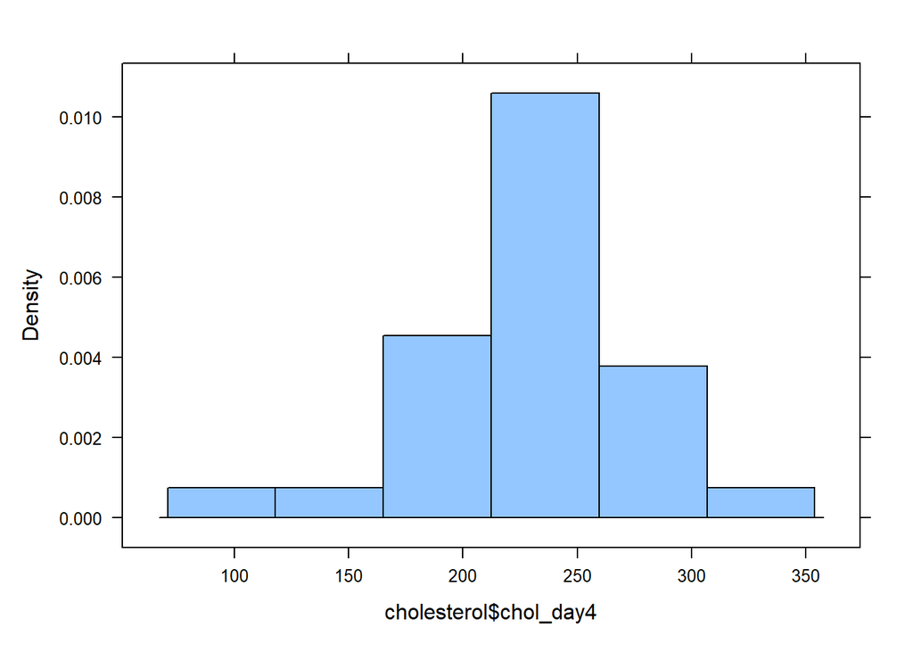

```r
histogram(cholesterol$chol_day4)
```

```r
fav <- favstats(cholesterol$chol_day4)
fav
```

```
 min    Q1 median    Q3 max     mean       sd  n missing
 116 201.5    235 250.5 352 230.6429 46.96745 28       0
```

## Step 3: Prepare the data for analysis

Decide how you are going to define the difference (chol_day2 - chol_day4 or chol_day4 - chol_day2).  
**I will define the difference as chol_day2 - chol_day4.**

What is your null and alternative hypotheses:

Create a qqPlot of the differences and determine if you can trust the statistical tests.

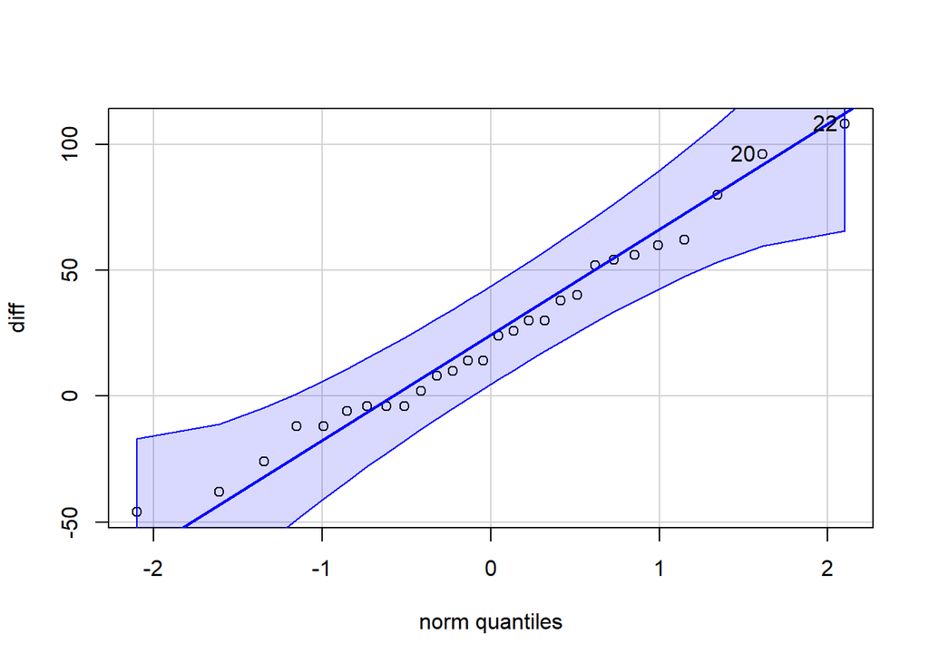

```
[1] 22 20
```

```r
diff <- cholesterol$chol_day2 - cholesterol$chol_day4
qqPlot(diff)
```

## Step 4: Perform the appropriate analysis

### Hypothesis Test

Perform a t-test for the differences.

```r
t_test_results <- t.test(diff, mu = 0, alternative = "less")

t_test_results
```

```
    One Sample t-test

data:  diff
t = 3.2189, df = 27, p-value = 0.9983
alternative hypothesis: true mean is less than 0
95 percent confidence interval:
     -Inf 35.60725
sample estimates:
mean of x
 23.28571
```

How many degrees of freedom does the test statistic have:  
**df = 27**

What is the test statistic:  
**t = 3.2189**

What is the P-value:  
**p-value = 0.9983**

### Confidence Interval

Create a 95% confidence interval for the difference in cholesterol scores:

```r
conf_int <- t_test_results$conf.int
conf_int
```

```
[1]     -Inf 35.60725
attr(,"conf.level")
[1] 0.95
```